# ST558 - Project 2

Tyler Pollard & Lucy Yin

# Introduction

For this report we will be using 6 models (4 linear regression, 1 random forest model, 1 boosted tree model) to make predictions on the total count of bike riders using data from the Bike Sharing Dataset (dataset can be found [here](https://archive.ics.uci.edu/ml/datasets/Bike+Sharing+Dataset)). This dataset contains hourly and daily count of registered, casual, and total sum of riders in the Capital bikeshare system, contributing variables include:

- season (winter, spring, summer, fall)
- year (2011, 2012)
- month of the year
- hour of the day
- holiday (yes, no)
- day of the week
- working day (yes or no)
- weather situation (mostly clear, mist, light precipitation, heavy precipitation)
- temperature
- feeling temperature
- humidity
- wind speed

There are 3 different types of response variables in the dataset:

- registered: registered riders who uses this bikeshare service regularly
- casual: un-registered riders who use this service casually or on occasions
- total: combined count of registered and casual riders

For our analysis, we will be working with almost all of the variables as predictors, and our response variable will be the total count of bike riders.

We will be selecting predictors using the `step()` function which chooses a model by AIC in a stepwise algorithm. As a result, which predictors we incorporate in our linear regression models and ensemble tree (specifically random forest and boosted tree) models may differ depending on which day of the week we look at. We’ll randomly split the data into training and test sets and fit the 6 models on the training set. Ultimately we will fit the 6 models on the test set and decide on which model produced the best prediction, which we judge by the smallest root mean squared error value.

# Data

```r
# read in data
hour.data <- read_csv("data/hour.csv") %>% as_tibble()
day.data <- read_csv("data/day.csv") %>% as_tibble()
```

```r
# correct the variable types
hour.data$season <- factor(hour.data$season)
levels(hour.data$season) <- list(winter = 1, spring = 2, summer = 3, fall = 4)

hour.data$yr <- factor(hour.data$yr)
levels(hour.data$yr) <- list("2011" = 0, "2012" = 1)

hour.data$weekday <- factor(hour.data$weekday)
levels(hour.data$weekday) <- list(monday = 1, tuesday = 2, wednesday = 3, thursday = 4, friday = 5, saturday = 6, sunday = 0)

hour.data$mnth <- factor(hour.data$mnth)
hour.data$hr <- factor(hour.data$hr)
hour.data$holiday <- factor(hour.data$holiday)
hour.data$workingday <- factor(hour.data$workingday)
hour.data$weathersit <- factor(hour.data$weathersit)

day.data$season <- factor(day.data$season)
levels(day.data$season) <- list(winter = 1, spring = 2, summer = 3, fall = 4)

day.data$yr <- factor(day.data$yr)
levels(day.data$yr) <- list("2011" = 0, "2012" = 1)

day.data$weekday <- factor(day.data$weekday)
levels(day.data$weekday) <- list(monday = 1, tuesday = 2, wednesday = 3, thursday = 4, friday = 5, saturday = 6, sunday = 0)

day.data$mnth <- factor(day.data$mnth)
day.data$holiday <- factor(day.data$holiday)
day.data$workingday <- factor(day.data$workingday)
day.data$weathersit <- factor(day.data$weathersit)
```

```r
# Temp Unnormal
temp.tmin = -8
temp.tmax = 39
hour.data$temp.unnormal <- hour.data$temp*(temp.tmax - temp.tmin) + temp.tmin # Unnormalize temp
hour.data$temp.F <- hour.data$temp.unnormal*(9/5) + 32 # Convert to Fahrenheit
day.data$temp.unnormal <- hour.data %>% group_by(dteday) %>% summarise(mean = mean(temp.unnormal)) %>% select(mean)
day.data$temp.unnormal <- day.data$temp.unnormal[[1]]
day.data$temp.F <- hour.data %>% group_by(dteday) %>% summarise(mean = mean(temp.F)) %>% select(mean)
day.data$temp.F <- day.data$temp.F[[1]]

# Atemp Unnormal
atemp.tmin = -16
atemp.tmax = 50
hour.data$atemp.unnormal <- hour.data$atemp*(atemp.tmax - atemp.tmin) + atemp.tmin # Unnormalize atemps
hour.data$atemp.F <- hour.data$atemp.unnormal*(9/5) + 32 # Convert to Fahrenheit
day.data$atemp.unnormal <- hour.data %>% group_by(dteday) %>% summarise(mean = mean(atemp.unnormal)) %>% select(mean)
day.data$atemp.unnormal <- day.data$atemp.unnormal[[1]]
day.data$atemp.F <- hour.data %>% group_by(dteday) %>% summarise(mean = mean(atemp.F)) %>% select(mean)
day.data$atemp.F <- day.data$atemp.F[[1]]

# Humidity Unnormal
day.data$hum.unnormal <- day.data$hum * 100
hour.data$hum.unnormal <- hour.data$hum * 100

# Windspeed Unnormal
day.data$windspeed.unnormal <- day.data$windspeed * 67
hour.data$windspeed.unnormal <- hour.data$windspeed * 67
```

```r
# add in a new variable before merging
hour.data <- mutate(hour.data, type = "hour")
day.data <- mutate(day.data, type = "day", hr = NA) %>% select(instant, dteday, season, yr, mnth, hr, everything())

# merge to create complete list of hour/day data
total.data <- rbind(hour.data, day.data)
```

```r
# filter out to one specific day of the week
hour.data <- hour.data %>% filter(weekday == params$weekday)
day.data <- day.data %>% filter(weekday == params$weekday)
total.data <- total.data %>% filter(weekday == params$weekday)
```

```r
# splitting data into training & test sets
set.seed(7)
train <- sample(1:nrow(day.data), size = nrow(day.data)*0.7)
test <- dplyr::setdiff(1:nrow(day.data), train)
day.training.data <- day.data[train, ]
day.test.data <- day.data[test, ]

hour.training.data <- hour.data[hour.data$dteday %in% day.training.data$dteday,]
hour.test.data <- hour.data[hour.data$dteday %in% day.test.data$dteday,]
```

# Summarization

## Contingency Tables

### Weather Situation

Below is a contingency table that shows the count of days that fall into the different categories of weather situation. This table will help justify the total count of riders because it can be expected that the number of casual riders, which influences the total count of riders, will be higher on nicer days that fall into the first two categories of Mostly clear and Mist.

```r
levels(day.training.data$weathersit) <- list(
  "Mostly clear" = "1",
  "Mist" = "2",
  "Light precipitation" = "3",
  "Heavy precipitation" = "4")
kable(t(table(day.training.data$weathersit)))
```

| Mostly clear | Mist | Light precipitation | Heavy precipitation |
| --- | --- | --- | --- |
| 42 | 27 | 3 | 0 |

### Year, Season and Count of Riders

```r
kable(table(day.training.data$season, cut(day.training.data$cnt, breaks = 2)), caption = "Occurrences of # Range of Riders of a given Season")
```

Occurrences of # Range of Riders of a given Season

|  | (676,4.22e+03] | (4.22e+03,7.77e+03] |
| --- | --- | --- |
| winter | 12 | 1 |
| spring | 5 | 13 |
| summer | 3 | 18 |
| fall | 8 | 12 |

```r
kable(table(day.training.data$yr, cut(day.training.data$cnt, breaks = 2)), caption = "Occurrences of # Range of Riders of a given Year")
```

Occurrences of # Range of Riders of a given Year

|  | (676,4.22e+03] | (4.22e+03,7.77e+03] |
| --- | --- | --- |
| 2011 | 21 | 15 |
| 2012 | 7 | 29 |

### Working Day and Count of Casual Riders

```r
levels(day.training.data$workingday) <- list("workday" = 1, "non-workday" = 0)
kable(table(day.training.data$workingday, cut(day.training.data$casual, breaks = 2)), caption = "Occurrences of # Range of Casual Riders of Workday vs. non-Workday")
```

Occurrences of # Range of Casual Riders of Workday vs. non-Workday

|  | (7.66,678] | (678,1.35e+03] |
| --- | --- | --- |
| workday | 45 | 27 |
| non-workday | 0 | 0 |

## Summary Tables

### Feeling Temperature

The summary tables of feeling temperature show the 5 number summary along with the mean and standard deviation of what the temperature actually felt like over the different years. The summary table for both the normalized and raw feeling temperatures are provided. These tables give insight to the range of feeling temperatures felt by the riders for the different years.

```r
# Normalized feeling temperature
atemp.summary <- hour.training.data %>% group_by(yr) %>% summarise(Min. = min(atemp), `1st Qu.` = quantile(atemp,0.25), Median = median(atemp), Mean = mean(atemp), `3rd Qu.` = quantile(atemp, 0.75), Max. = max(atemp), `St. Dev.` = sd(atemp))
kable(atemp.summary, digits = 2, caption = "Summary of feeling temperatures by year")
```

Summary of feeling temperatures by year

| yr | Min. | 1st Qu. | Median | Mean | 3rd Qu. | Max. | St. Dev. |
| --- | --- | --- | --- | --- | --- | --- | --- |
| 2011 | 0.11 | 0.39 | 0.52 | 0.49 | 0.62 | 0.85 | 0.17 |
| 2012 | 0.08 | 0.35 | 0.52 | 0.50 | 0.64 | 0.83 | 0.17 |

```r
# Raw feeling temperature in Farenheit
atemp.summary.unnormal <- hour.training.data %>% group_by(yr) %>% summarise(Min. = min(atemp.F), `1st Qu.` = quantile(atemp.F,0.25), Median = median(atemp.F), Mean = mean(atemp.F), `3rd Qu.` = quantile(atemp.F, 0.75), Max. = max(atemp.F), `St. Dev.` = sd(atemp.F))
kable(atemp.summary.unnormal, digits = 2, caption = "Summary of feeling temperatures by year")
```

Summary of feeling temperatures by year

| yr | Min. | 1st Qu. | Median | Mean | 3rd Qu. | Max. | St. Dev. |
| --- | --- | --- | --- | --- | --- | --- | --- |
| 2011 | 15.80 | 50.0 | 64.41 | 61.73 | 77.0 | 104.0 | 20.68 |
| 2012 | 12.21 | 44.6 | 64.41 | 62.51 | 78.8 | 102.2 | 19.97 |

### Humidity

```r
kable(t(c(summary(day.training.data$hum), St.Dev. = sd(day.training.data$hum))), digits = 2, caption = "Normalized Humidity")
```

Normalized Humidity

| Min. | 1st Qu. | Median | Mean | 3rd Qu. | Max. | St.Dev. |
| --- | --- | --- | --- | --- | --- | --- |
| 0.29 | 0.55 | 0.66 | 0.64 | 0.74 | 0.96 | 0.14 |

```r
kable(t(c(summary(day.training.data$hum.unnormal), St.Dev. = sd(day.training.data$hum.unnormal))), digits = 2, caption = "Raw Humidity")
```

Raw Humidity

| Min. | 1st Qu. | Median | Mean | 3rd Qu. | Max. | St.Dev. |
| --- | --- | --- | --- | --- | --- | --- |
| 29 | 55.4 | 65.53 | 64.28 | 73.51 | 96.25 | 14.22 |

### Wind Speed

```r
kable(t(c(summary(day.training.data$windspeed), St.Dev. = sd(day.training.data$windspeed))), digits = 2, caption = "Normalized Wind Speed")
```

Normalized Wind Speed

| Min. | 1st Qu. | Median | Mean | 3rd Qu. | Max. | St.Dev. |
| --- | --- | --- | --- | --- | --- | --- |
| 0.05 | 0.13 | 0.18 | 0.19 | 0.24 | 0.37 | 0.08 |

```r
kable(t(c(summary(day.training.data$windspeed.unnormal), St.Dev. = sd(day.training.data$windspeed.unnormal))), digits = 2, caption = "Raw Wind Speed ")
```

Raw Wind Speed

| Min. | 1st Qu. | Median | Mean | 3rd Qu. | Max. | St.Dev. |
| --- | --- | --- | --- | --- | --- | --- |
| 3.57 | 8.74 | 11.94 | 12.67 | 15.83 | 24.5 | 5.21 |

## Histograms

### Humidity and Windspeed Distributions

The following density plots show the distribution of the weather effects for raw humidity and raw wind speed over the span of the biker data. These distributions provide insight on what values for each weather effect can be expected and how the combination of each effect may drive the different weather situations and in turn the expected count of riders.

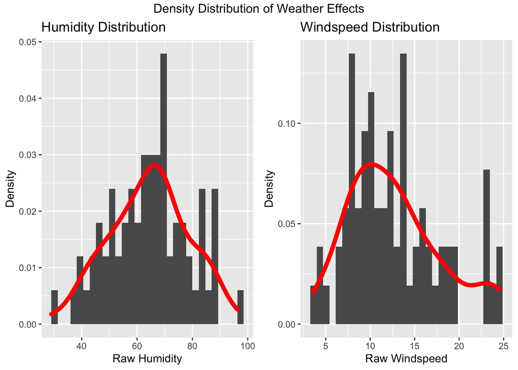

```r
hum.histogram <- ggplot(data = day.training.data, aes(x = hum.unnormal)) +
  geom_histogram(aes(y = ..density..), bins = 30) +
  geom_density(color = "red", size = 2) +
  labs(title = "Humidity Distribution", x = "Raw Humidity", y = "Density")
windspeed.histogram <- ggplot(data = day.training.data, aes(x = windspeed.unnormal)) +
  geom_histogram(aes(y = ..density..), bins = 30) +
  geom_density(color = "red", size = 2) +
  labs(title = "Windspeed Distribution", x = "Raw Windspeed", y = "Density")
grid.arrange(hum.histogram, windspeed.histogram, ncol = 2, top = "Density Distribution of Weather Effects")
```

## Density Plot

### Casual Riders and Weather Situation

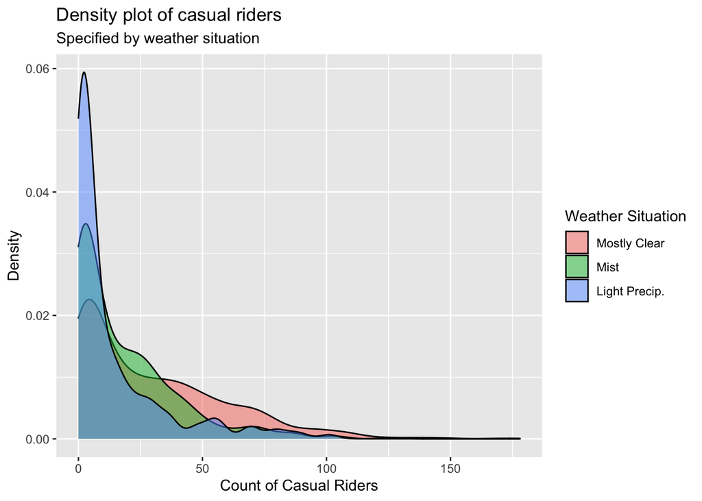

```r
ggplot(hour.training.data, aes(x = casual)) +
  geom_density(alpha = 0.5, aes(fill = weathersit)) +
  labs(title = "Density plot of casual riders",
       subtitle = "Specified by weather situation",
       x = "Count of Casual Riders",
       y = "Density") +
  scale_fill_discrete(name = "Weather Situation", labels = c("Mostly Clear", "Mist", "Light Precip.", "Heavy Precip."))
```

### Registered Riders and Weather Situation

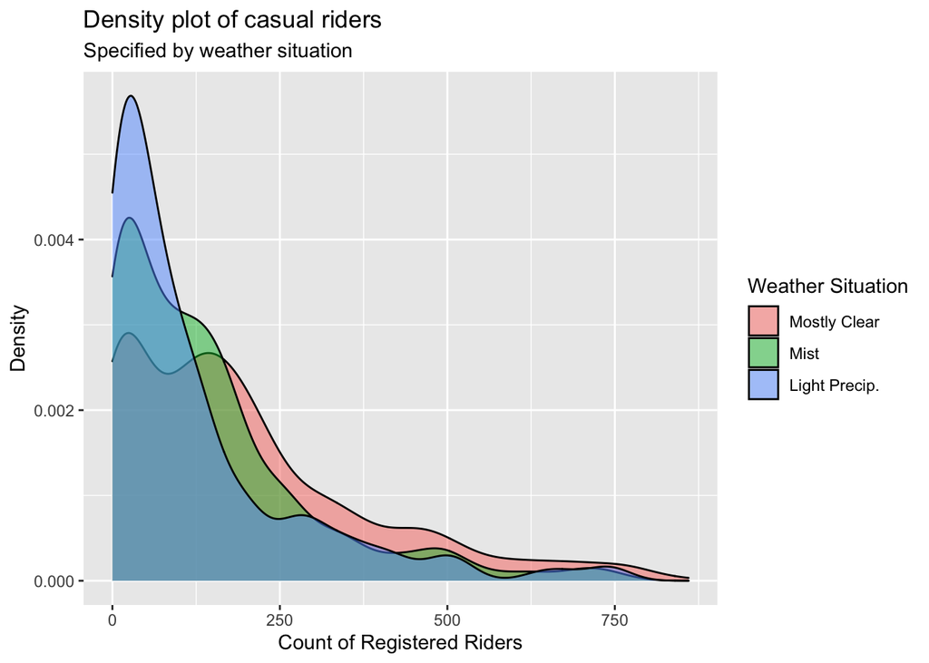

```r
ggplot(hour.training.data, aes(x = registered)) +
  geom_density(alpha = 0.5, aes(fill = weathersit)) +
  labs(title = "Density plot of casual riders",
       subtitle = "Specified by weather situation",
       x = "Count of Registered Riders",
       y = "Density") +
  scale_fill_discrete(name = "Weather Situation", labels = c("Mostly Clear", "Mist", "Light Precip.", "Heavy Precip."))
```

### Total Riders and Weather Situation

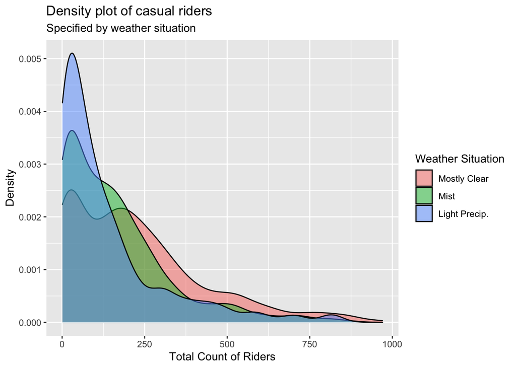

```r
ggplot(hour.training.data, aes(x = cnt)) +
  geom_density(alpha = 0.5, aes(fill = weathersit)) +
  labs(title = "Density plot of casual riders",
       subtitle = "Specified by weather situation",
       x = "Total Count of Riders",
       y = "Density") +
  scale_fill_discrete(name = "Weather Situation", labels = c("Mostly Clear", "Mist", "Light Precip.", "Heavy Precip."))
```

### Casual Riders and Holiday

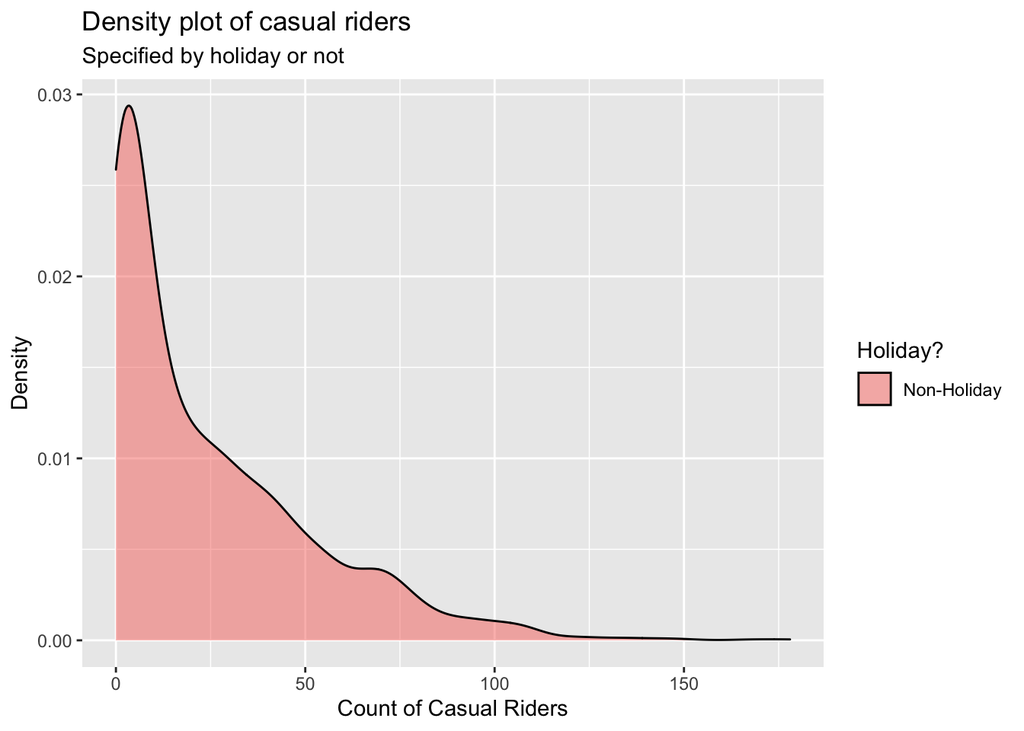

```r
ggplot(hour.training.data, aes(x = casual)) +
  geom_density(alpha = 0.5, aes(fill = holiday)) +
  labs(title = "Density plot of casual riders",
       subtitle = "Specified by holiday or not",
       x = "Count of Casual Riders",
       y = "Density") +
  scale_fill_discrete(name = "Holiday?", labels = c("Non-Holiday", "Holiday"))
```

### Registered Riders and Holiday

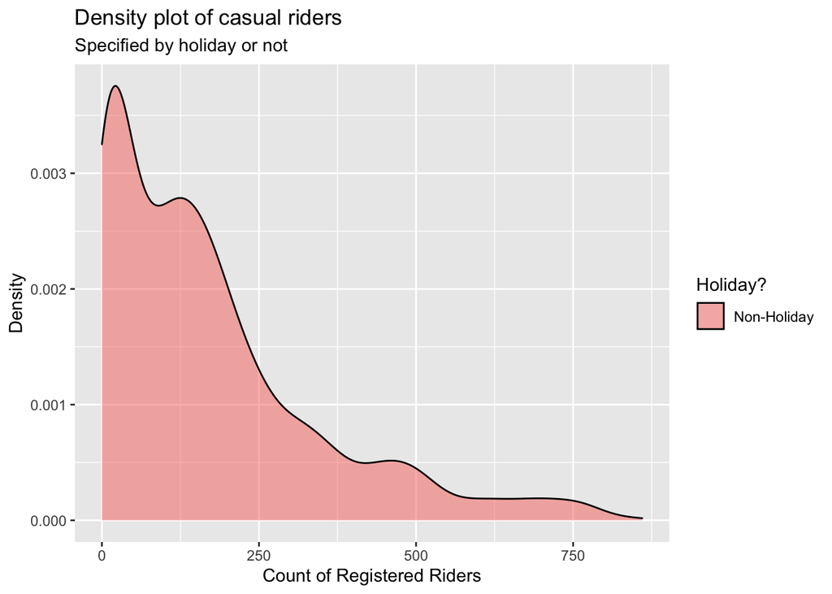

```r
ggplot(hour.training.data, aes(x = registered)) +
  geom_density(alpha = 0.5, aes(fill = holiday)) +
  labs(title = "Density plot of casual riders",
       subtitle = "Specified by holiday or not",
       x = "Count of Registered Riders",
       y = "Density") +
  scale_fill_discrete(name = "Holiday?", labels = c("Non-Holiday", "Holiday"))
```

### Total Riders and Holiday

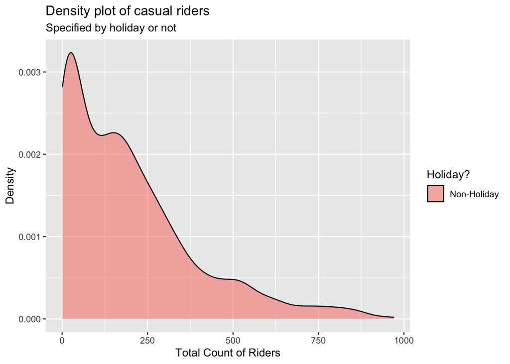

```r
ggplot(hour.training.data, aes(x = cnt)) +
  geom_density(alpha = 0.5, aes(fill = holiday)) +
  labs(title = "Density plot of casual riders",
       subtitle = "Specified by holiday or not",
       x = "Total Count of Riders",
       y = "Density") +
  scale_fill_discrete(name = "Holiday?", labels = c("Non-Holiday", "Holiday"))
```

## Boxplots

### Feeling Temperature Over the Year

To get a better understanding of the feeling temperature spreads over the year, boxplots of the feeling temperature are plotted by month with the data points for each day used to create them plotted overtop. Intuitively, it can be expected that the feeling temperature rises from the beginning of the year into the middle of summer and then drops back down over the fall and winter months. These boxplots provide insight into the possible number of rider flucuation over the different months of the year.

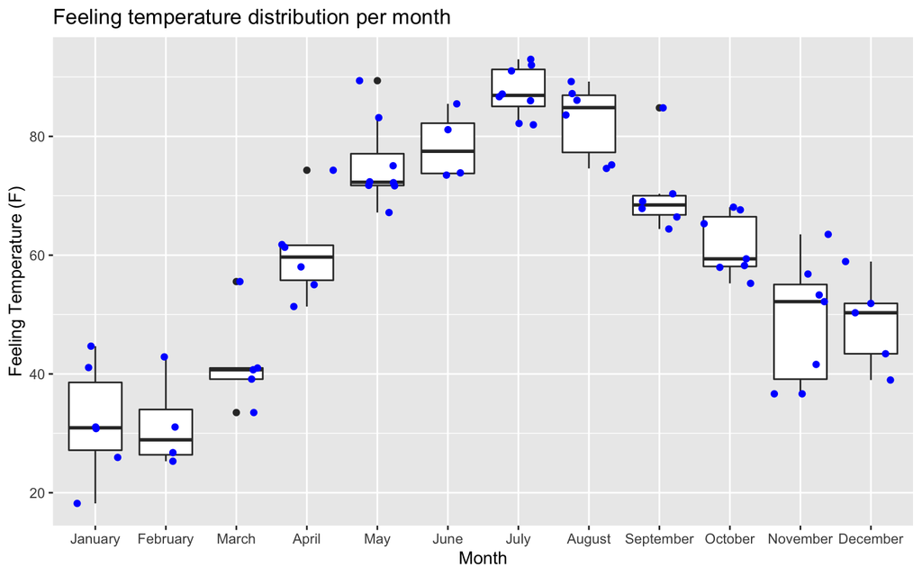

```r
atemp.boxplot.df <- day.training.data
levels(atemp.boxplot.df$mnth) <- list(January = 1, February = 2, March = 3, April = 4, May = 5, June = 6, July = 7, August = 8, September = 9, October = 10, November = 11, December = 12)
ggplot(data = atemp.boxplot.df, aes(x = mnth, y = atemp.F)) +
  geom_boxplot() +
  geom_point(position = "jitter", color = "blue") +
  labs(title = "Feeling temperature distribution per month", x = "Month", y = "Feeling Temperature (F)")
```

### Riders of Every Hour and Weather Situation

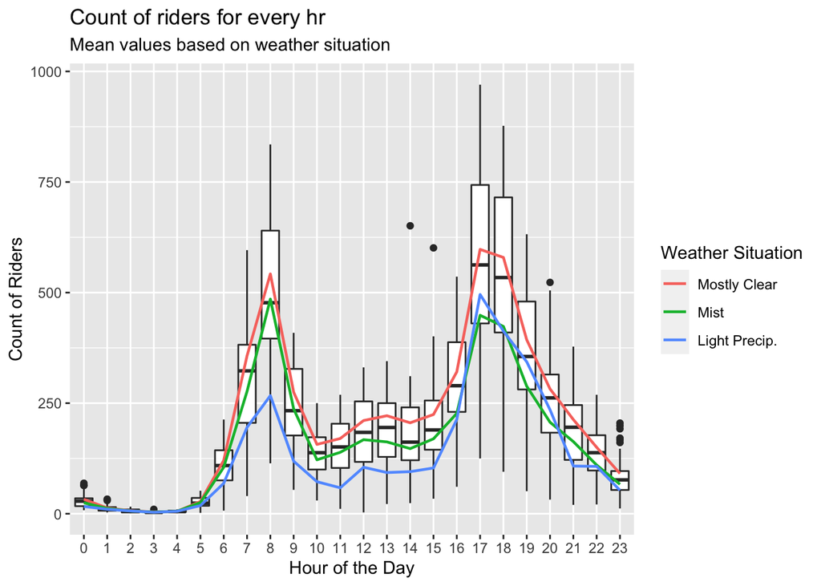

```r
ggplot(hour.training.data, aes(x = hr, y = cnt)) +
  geom_boxplot() +
  stat_summary(fun = mean, geom = "line", lwd = 0.8, aes(group = weathersit, col = weathersit)) +
  labs(title = "Count of riders for every hr",
       subtitle = "Mean values based on weather situation",
       x = "Hour of the Day",
       y = "Count of Riders") +
  scale_color_discrete(name = "Weather Situation", labels = c("Mostly Clear", "Mist", "Light Precip.", "Heavy Precip."))
```

## Scatter Plots

### Count vs Casual by Season

These four scatter plots show the relation between the total number of riders and casual riders by day with linear models plotted overtop parsed by season. These plots show how the number of casual riders contribute to the total count of riders for each season. The greater the slope of the linear model correlates to a greater number of causal riders contributing to the total count of riders.

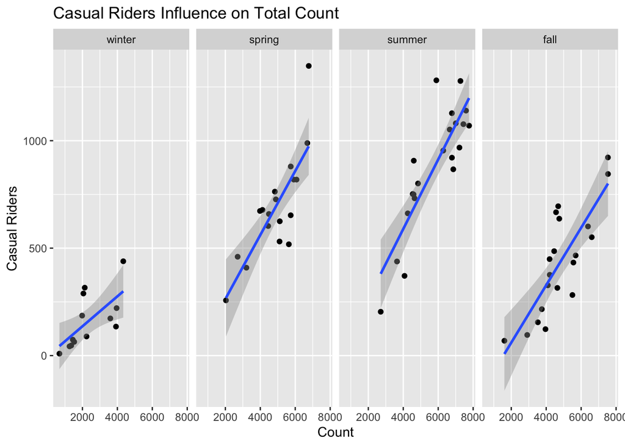

```r
ggplot(data = day.training.data, aes(x = cnt, y = casual)) +
  geom_point() +
  geom_smooth(method = "lm") +
  facet_grid(cols = vars(season)) +
  labs(title = "Casual Riders Influence on Total Count", x = "Count", y = "Casual Riders")
```

### Riders vs Temperature

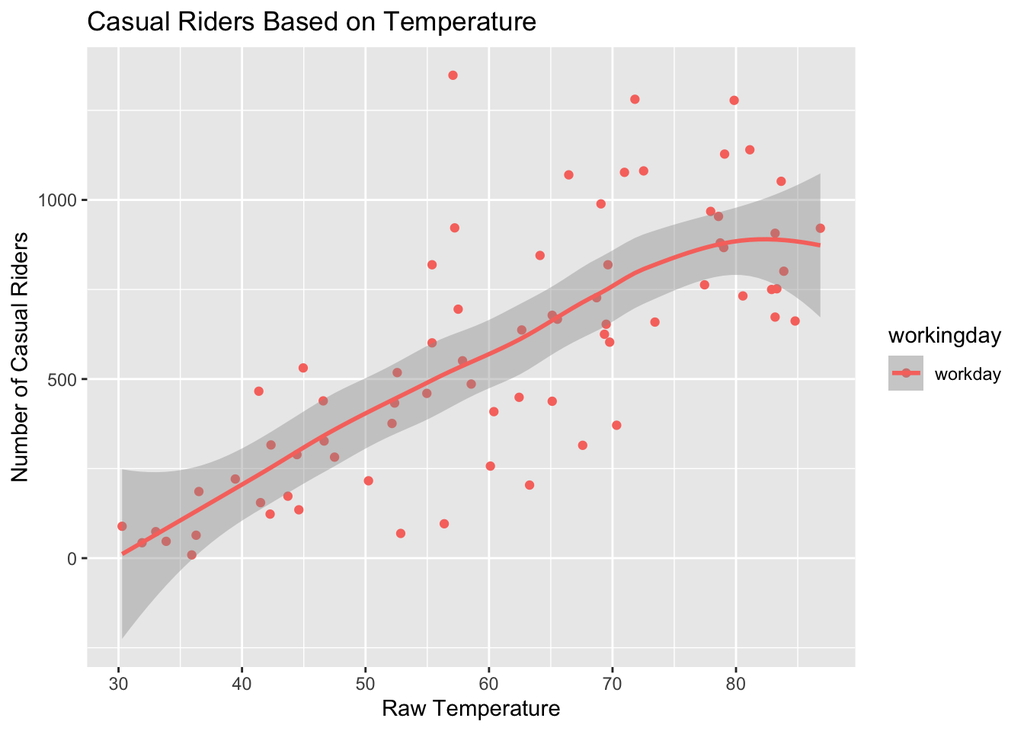

```r
day.training.data$temp.indicator <- ifelse(day.training.data$temp < mean(day.training.data$temp), 0, 1)
day.training.data$temp.indicator <- as_factor(day.training.data$temp.indicator)
levels(day.training.data$temp.indicator) <- list("Low Temperature" = 0, "High Temperature" = 1)
ggplot(data = day.training.data, aes(x = temp.F, y = casual, color = workingday)) +
  geom_point() +
  geom_smooth() +
  labs(title = "Casual Riders Based on Temperature", x = "Raw Temperature", y = "Number of Casual Riders")
```

### Riders vs. Hour vs. Month vs. Working Day

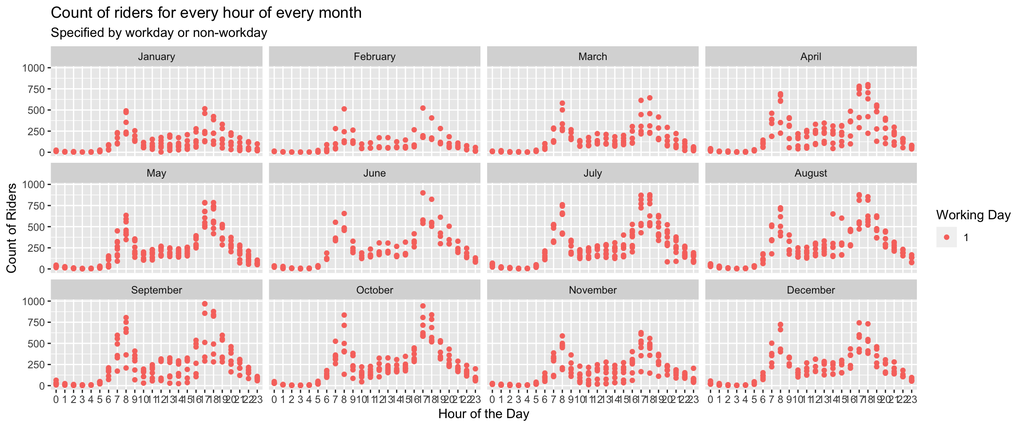

```r
count.df <- hour.training.data
levels(count.df$mnth) <- list(January = 1, February = 2, March = 3, April = 4, May = 5, June = 6, July = 7, August = 8, September = 9, October = 10, November = 11, December = 12)
ggplot(count.df, aes(x = hr, y = cnt)) +
  geom_point(aes(col = workingday)) +
  facet_wrap(vars(mnth)) +
  labs(title = "Count of riders for every hour of every month",
       subtitle = "Specified by workday or non-workday",
       x = "Hour of the Day",
       y = "Count of Riders") +
  scale_color_discrete(name = "Working Day")
```

## Correlation Plot

### Correlation between temp, atemp, hum, windspeed

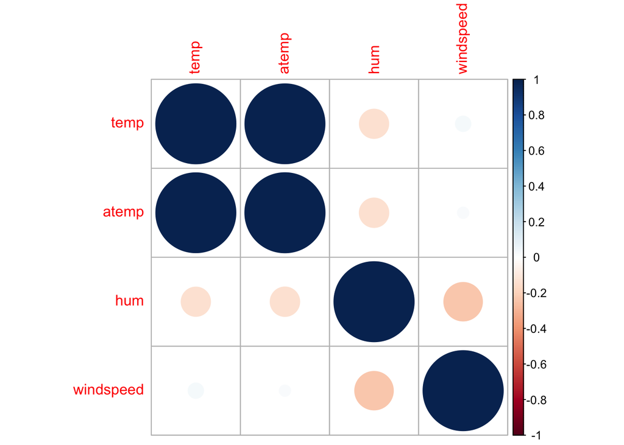

```r
cor.variables <- hour.training.data %>% select(temp, atemp, hum, windspeed)
correlation <- cor(cor.variables, method = "spearman")
corrplot(correlation)
```

## Plots with GGally

### Using Day Data

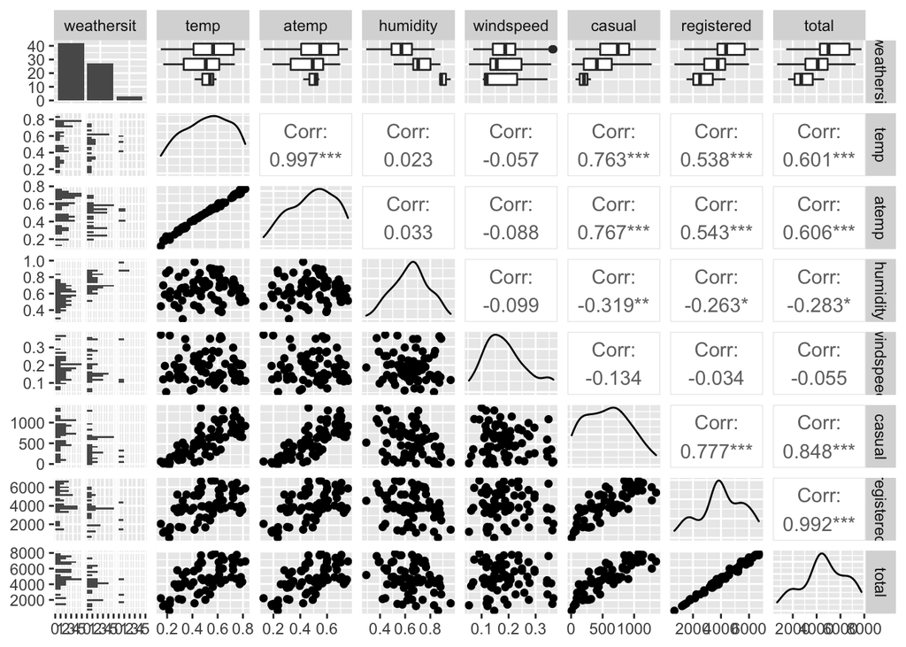

```r
subset.data.day <- data_frame(weathersit=day.training.data$weathersit, temp=day.training.data$temp, atemp=day.training.data$atemp,humidity=day.training.data$hum, windspeed=day.training.data$windspeed, casual=day.training.data$casual, registered=day.training.data$registered, total=day.training.data$cnt)
GGally::ggpairs(subset.data.day)
```

### Using Hour Data

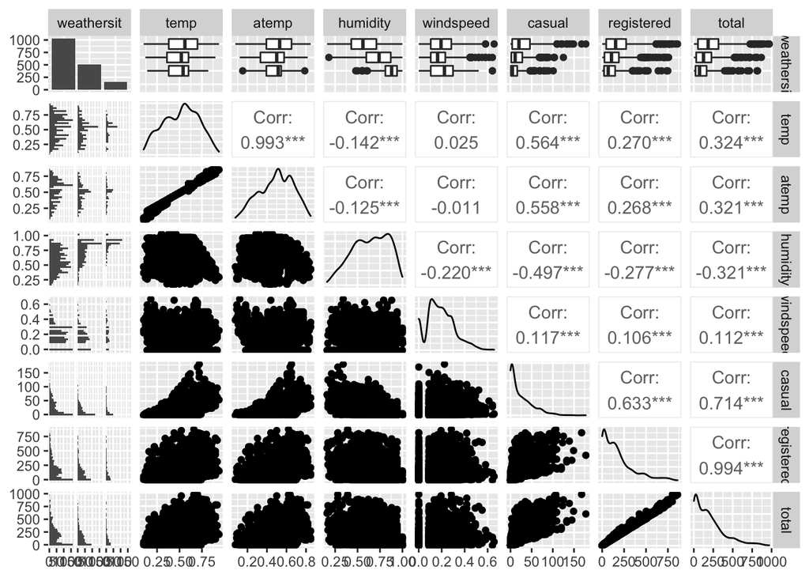

```r
subset.data.hr <- data_frame(weathersit=hour.training.data$weathersit, temp=hour.training.data$temp, atemp=hour.training.data$atemp,humidity=hour.training.data$hum, windspeed=hour.training.data$windspeed, casual=hour.training.data$casual, registered=hour.training.data$registered, total=hour.training.data$cnt)
GGally::ggpairs(subset.data.hr)
```

# Modeling

## Linear Regression Model

### What is Linear Regression Model (tyler)

Linear regression is a type of modeling used to predict a response based on explainatory variables by fitting a linear equation to observed data. For simple linear regression using a single explainatory variable to predict a response variable the equation is ${Y}_{i} = \beta_{0} + \beta_{1}{x}_{i} + {E}_{i}$ where ${Y}_{i}$ is the response for the ${i}^{th}$ observation, ${x}_{i}$ is the value of the explanatory variable for the ${i}^{th}$ observation, $\beta_{0}$ is the y-intercept, $\beta_{1}$ is the slope, and ${E}_{i}$ is the error for the ${i}^{th}$ observation. Fitting a linear model to the observed dataset requires estimating the coefficients $\beta$ such that the error term ${E}_{i} = {Y}_{i} - \beta_{0} - \beta_{1}{x}_{i}$ is minimized. The most common way to minimize this term is through least-squares where we minimize the sum of squared residuals through $min_{\beta_{0},\beta_{1}}\sum_{i=1}^n ({y}_{i} - \beta_{0} - \beta_{1}{x}_{i})$. Simple linear regression can be extended in many ways to include:

- higher order terms: ${Y}_{i} = \beta_{0} + \beta_{1}{x}_{i} + \beta_{2}{x}_{i}^{2} + {E}_{i}$
- more explanatory variables: ${Y}_{i} = \beta_{0} + \beta_{1}{x}_{1i} + \beta_{2}{x}_{2i} + \beta_{3}{x}_{1i}{x}_{2i} + {E}_{i}$
- more explanatory variables and higher order terms: ${Y}_{i} = \beta_{0} + \beta_{1}{x}_{1i} + \beta_{2}{x}_{2i} + \beta_{3}{x}_{1i}{x}_{2i} + \beta_{4}{x}_{1i}^{2} + \beta_{5}{x}_{2i}^{2} + {E}_{i}$

### Picking predictors using AIC

```r
# keep only variables that are relevant to modeling
if.weekday <- hour.training.data %>% filter(weekday == params$weekday) %>% select(workingday) %>% unique() %>% nrow()
if.holiday <- hour.training.data %>% filter(weekday == params$weekday) %>% select(holiday) %>% unique() %>% nrow()

# use function to decide if a weekday has 1 factored levels
# if so we will not use these factors in the model
get.data <- function(weekday, ...){
  if (if.weekday == 1 & if.holiday == 1) {
    hour.training.data2 <- hour.training.data %>% select(season, yr, mnth, hr, weathersit, temp.F, atemp.F, hum.unnormal, windspeed.unnormal, cnt)
  }
  else {
    hour.training.data2 <- hour.training.data %>% select(season, yr, mnth, hr, holiday, workingday, weathersit, temp.F, atemp.F, hum.unnormal, windspeed.unnormal, cnt)
  }
  hour.training.data2
}
hour.training.data2 <- get.data(params$weekday)
```

```r
# aic using only 1st ordered terms
fit.aic <- step((lm(cnt ~ ., data = hour.training.data2, verbose = FALSE)), direction = "both")
```

```
## Start:  AIC=14677.73
## cnt ~ season + yr + mnth + hr + weathersit + temp.F + atemp.F +
##     hum.unnormal + windspeed.unnormal
##
##                      Df Sum of Sq      RSS   AIC
## - season              3     28081  8968116 14677
## <none>                             8940035 14678
## - temp.F              1     23073  8963108 14680
## - windspeed.unnormal  1     32748  8972783 14682
## - mnth               11    190206  9130241 14692
## - atemp.F             1     84501  9024536 14692
## - hum.unnormal        1    211228  9151263 14716
## - weathersit          2    294260  9234295 14729
## - yr                  1   2909060 11849095 15156
## - hr                 23  37355743 46295778 17432
##
## Step:  AIC=14677.07
## cnt ~ yr + mnth + hr + weathersit + temp.F + atemp.F + hum.unnormal +
##     windspeed.unnormal
##
##                      Df Sum of Sq      RSS   AIC
## <none>                             8968116 14677
## + season              3     28081  8940035 14678
## - windspeed.unnormal  1     29834  8997950 14681
## - temp.F              1     32659  9000775 14681
## - atemp.F             1    103915  9072032 14695
## - hum.unnormal        1    231618  9199735 14718
## - weathersit          2    303427  9271543 14730
## - mnth               11    855640  9823756 14810
## - yr                  1   3015932 11984048 15169
## - hr                 23  37355151 46323267 17427
```

```r
# aic including squared terms and interactions
fit.aic2 <- step((lm(cnt ~ .^2 + I(temp.F^2) + I(atemp.F^2) + I(hum.unnormal^2) + I(windspeed.unnormal^2), data = hour.training.data2, verbose = FALSE)), direction = "both")
```

```
## Start:  AIC=13194.43
## cnt ~ (season + yr + mnth + hr + weathersit + temp.F + atemp.F +
##     hum.unnormal + windspeed.unnormal)^2 + I(temp.F^2) + I(atemp.F^2) +
##     I(hum.unnormal^2) + I(windspeed.unnormal^2)
##
##
## Step:  AIC=13194.43
## cnt ~ season + yr + mnth + hr + weathersit + temp.F + atemp.F +
##     hum.unnormal + windspeed.unnormal + I(temp.F^2) + I(atemp.F^2) +
##     I(hum.unnormal^2) + I(windspeed.unnormal^2) + season:yr +
##     season:hr + season:weathersit + season:temp.F + season:atemp.F +
##     season:hum.unnormal + season:windspeed.unnormal + yr:mnth +
##     yr:hr + yr:weathersit + yr:temp.F + yr:atemp.F + yr:hum.unnormal +
##     yr:windspeed.unnormal + mnth:hr + mnth:weathersit + mnth:temp.F +
##     mnth:atemp.F + mnth:hum.unnormal + mnth:windspeed.unnormal +
##     hr:weathersit + hr:temp.F + hr:atemp.F + hr:hum.unnormal +
##     hr:windspeed.unnormal + weathersit:temp.F + weathersit:atemp.F +
##     weathersit:hum.unnormal + weathersit:windspeed.unnormal +
##     temp.F:atemp.F + temp.F:hum.unnormal + temp.F:windspeed.unnormal +
##     atemp.F:hum.unnormal + atemp.F:windspeed.unnormal + hum.unnormal:windspeed.unnormal
##
##                                    Df Sum of Sq     RSS   AIC
## - mnth:hr                         249    439985 2298177 13058
## - season:hr                        65     56904 1915096 13116
## - hr:hum.unnormal                  23     31128 1889321 13177
## - mnth:weathersit                  19     30005 1888197 13184
## - mnth:atemp.F                     10     14396 1872588 13188
## - mnth:windspeed.unnormal          10     16050 1874242 13189
## - season:windspeed.unnormal         2         2 1858195 13190
## - season:hum.unnormal               2       172 1858364 13191
## - season:atemp.F                    2      1112 1859305 13191
## - atemp.F:windspeed.unnormal        1        76 1858268 13192
## - season:weathersit                 3      4458 1862650 13192
## - weathersit:windspeed.unnormal     2      2328 1860520 13193
## - season:yr                         1       550 1858742 13193
## - temp.F:windspeed.unnormal         1       886 1859078 13193
## - yr:hum.unnormal                   1      1246 1859438 13194
## - I(windspeed.unnormal^2)           1      1310 1859503 13194
## - mnth:temp.F                      10     21640 1879832 13194
## - I(temp.F^2)                       1      1880 1860072 13194
```

[output cut: 1028 more lines]

```
## + mnth:windspeed.unnormal          11     15131 2527065 12968
## + hr:temp.F                        23     49430 2492766 12969
## - season:weathersit                 6     48369 2590564 12976
## + hr:hum.unnormal                  23     37097 2505099 12977
## + mnth:weathersit                  19     22694 2519501 12979
## + hr:windspeed.unnormal            23     32447 2509749 12980
## - temp.F:atemp.F                    1     63483 2605678 12996
## - yr:mnth                           9     90566 2632761 12998
## - mnth:hum.unnormal                11    125138 2667333 13016
## - weathersit:hum.unnormal           2    119991 2662186 13031
## - season:hr                        69    427239 2969435 13083
## + mnth:hr                         253    427027 2115168 13149
## - hr:weathersit                    46    583624 3125819 13216
## - hr:atemp.F                       23    584486 3126681 13263
## - yr:hr                            23   1801513 4343708 13822
```

```r
# aic using 1st order and interactions
fit.aic3 <- step((lm(cnt ~.^2, data = hour.training.data2, verbose = FALSE)), direction = "both")
```

```
## Start:  AIC=13194.31
## cnt ~ (season + yr + mnth + hr + weathersit + temp.F + atemp.F +
##     hum.unnormal + windspeed.unnormal)^2
##
##
## Step:  AIC=13194.31
## cnt ~ season + yr + mnth + hr + weathersit + temp.F + atemp.F +
##     hum.unnormal + windspeed.unnormal + season:yr + season:hr +
##     season:weathersit + season:temp.F + season:atemp.F + season:hum.unnormal +
##     season:windspeed.unnormal + yr:mnth + yr:hr + yr:weathersit +
##     yr:temp.F + yr:atemp.F + yr:hum.unnormal + yr:windspeed.unnormal +
##     mnth:hr + mnth:weathersit + mnth:temp.F + mnth:atemp.F +
##     mnth:hum.unnormal + mnth:windspeed.unnormal + hr:weathersit +
##     hr:temp.F + hr:atemp.F + hr:hum.unnormal + hr:windspeed.unnormal +
##     weathersit:temp.F + weathersit:atemp.F + weathersit:hum.unnormal +
##     weathersit:windspeed.unnormal + temp.F:atemp.F + temp.F:hum.unnormal +
##     temp.F:windspeed.unnormal + atemp.F:hum.unnormal + atemp.F:windspeed.unnormal +
##     hum.unnormal:windspeed.unnormal
##
##                                    Df Sum of Sq     RSS   AIC
## - mnth:hr                         249    439788 2306594 13057
## - season:hr                        65     60121 1926928 13118
## - hr:hum.unnormal                  23     30387 1897194 13176
## - mnth:weathersit                  19     28460 1895266 13182
## - mnth:windspeed.unnormal          10     15031 1881837 13188
## - season:windspeed.unnormal         2       101 1866908 13190
## - season:hum.unnormal               2       408 1867214 13191
## - season:weathersit                 3      3424 1870230 13191
## - season:atemp.F                    2      1302 1868109 13192
## - atemp.F:windspeed.unnormal        1         7 1866814 13192
## - weathersit:windspeed.unnormal     2      2417 1869224 13192
## - season:yr                         1       445 1867251 13193
## - mnth:atemp.F                     10     20293 1887099 13193
## - yr:hum.unnormal                   1       643 1867450 13193
## - temp.F:windspeed.unnormal         1      1715 1868521 13194
## <none>                                          1866806 13194
## - yr:windspeed.unnormal             1      2361 1869168 13194
## - season:temp.F                     2      4936 1871742 13195
## - hr:windspeed.unnormal            23     51768 1918575 13195
## - weathersit:atemp.F                2      5049 1871855 13195
```

[output cut: 833 more lines]

```
## + mnth:windspeed.unnormal          11      6413 2540599 12973
## - season:atemp.F                    3     39647 2586660 12976
## - yr:atemp.F                        1     35052 2582065 12977
## + hr:hum.unnormal                  23     33475 2513537 12979
## + hr:windspeed.unnormal            23     31934 2515079 12980
## + mnth:weathersit                  19     18727 2528285 12981
## - temp.F:atemp.F                    1     54612 2601624 12990
## - mnth:hum.unnormal                11    109282 2656294 13005
## - yr:mnth                           9    104514 2651527 13006
## - weathersit:hum.unnormal           2    125353 2672365 13033
## - season:hr                        69    447473 2994485 13093
## + mnth:hr                         252    429644 2117369 13145
## - hr:weathersit                    46    591600 3138613 13219
## - hr:atemp.F                       23    567081 3114094 13252
## - yr:hr                            23   1809266 4356278 13823
```

### Modeling using AIC picked predictors

```r
# use all predictors except atemp and holiday
set.seed(7)
fit.mlr0 <- train(cnt ~ season + yr + mnth + hr + workingday + weathersit + temp.F + hum.unnormal + windspeed.unnormal,
                  data = hour.training.data,
                  method = "lm",
                  preProcess = c("center", "scale"),
                  trControl = trainControl(method = "cv", number = 10))
fit.mlr0
```

```
## Linear Regression
##
## 1703 samples
##    9 predictor
##
## Pre-processing: centered (45), scaled (45)
## Resampling: Cross-Validated (10 fold)
## Summary of sample sizes: 1532, 1532, 1532, 1532, 1532, 1534, ...
## Resampling results:
##
##   RMSE      Rsquared  MAE
##   74.72557  0.848889  52.78131
##
## Tuning parameter 'intercept' was held constant at a value of TRUE
```

```r
# Examine performance of this multiple linear regression model on the test data after prediction
predict.mlr0 <- postResample(predict(fit.mlr0, newdata = hour.test.data), obs = hour.test.data$cnt)
```

```r
# use aic predictors (1st ordered terms)
set.seed(7)
fit.mlr1 <- train(fit.aic$terms,
                  data = hour.training.data2,
                  method = "lm",
                  preProcess = c("center", "scale"),
                  trControl = trainControl(method = "cv", number = 10))
fit.mlr1
```

```
## Linear Regression
##
## 1703 samples
##    8 predictor
##
## Pre-processing: centered (42), scaled (42)
## Resampling: Cross-Validated (10 fold)
## Summary of sample sizes: 1532, 1532, 1532, 1532, 1532, 1534, ...
## Resampling results:
##
##   RMSE      Rsquared   MAE
##   74.33315  0.8506088  52.54417
##
## Tuning parameter 'intercept' was held constant at a value of TRUE
```

```r
# Examine performance of this multiple linear regression model on the test data after prediction
predict.mlr1 <- postResample(predict(fit.mlr1, newdata = hour.test.data), obs = hour.test.data$cnt)

# use aic predictors (2nd ordered terms and interactions)
set.seed(7)
fit.mlr2 <- train(fit.aic2$terms,
                  data = hour.training.data2,
                  method = "lm",
                  preProcess = c("center", "scale"),
                  trControl = trainControl(method = "cv", number = 10))
fit.mlr2
```

```
## Linear Regression
##
## 1703 samples
##    9 predictor
##
## Pre-processing: centered (287), scaled (287)
## Resampling: Cross-Validated (10 fold)
## Summary of sample sizes: 1532, 1532, 1532, 1532, 1532, 1534, ...
## Resampling results:
##
##   RMSE      Rsquared   MAE
##   46.41857  0.9415467  30.70593
##
## Tuning parameter 'intercept' was held constant at a value of TRUE
```

```r
# Examine performance of this multiple linear regression model on the test data after prediction
predict.mlr2 <- postResample(predict(fit.mlr2, newdata = hour.test.data), obs = hour.test.data$cnt)

# use aic predictors (1st order and interactions)
set.seed(7)
fit.mlr3 <- train(fit.aic3$terms,
                  data = hour.training.data2,
                  method = "lm",
                  preProcess = c("center", "scale"),
                  trControl = trainControl(method = "cv", number = 10))
fit.mlr3
```

```
## Linear Regression
##
## 1703 samples
##    9 predictor
##
## Pre-processing: centered (285), scaled (285)
## Resampling: Cross-Validated (10 fold)
## Summary of sample sizes: 1532, 1532, 1532, 1532, 1532, 1534, ...
## Resampling results:
##
##   RMSE     Rsquared   MAE
##   46.3243  0.9417153  30.54715
##
## Tuning parameter 'intercept' was held constant at a value of TRUE
```

```r
# Examine performance of this multiple linear regression model on the test data after prediction
predict.mlr3 <- postResample(predict(fit.mlr3, newdata = hour.test.data), obs = hour.test.data$cnt)
```

## Ensemble Tree Model

### Random Forest Model

The random forest model is a type of tree based method where we create multiple trees from bootstrap samples of the data and then average the results. This process is done by first creating a bootstrap sample of the data and then training a tree on this sample where we call the prediction for a given set of $x$ values $\hat{y}^{*1}(x)$. This process is then repeated a $B$ number of times to obtain $\hat{y}^{*j}(x), j = 1,...,B$. The final prediction is the average of these predictions $\hat{y}(x) = \frac{1}{B}\sum_{j=1}^{B}\hat{y}^{*j}(x)$. For each of these bootstrap sample/tree fits a random subset of predictors is chosen becasue if a really strong predictor exists, every bootstrap tree will probably use it as the first split. By selecting a subset of predictors, a good predictor or two won’t dominate the tree fits. The number of predictors for a random forest regression tree is usually $m = p/3$ where $m$ is the random predictors chosen and $p$ is the full set of possible predictors. Cross-validation can also be used to select these random predictors as we did in our random forest model.

```r
# Fit random forest model
set.seed(7)
fit.random.forest.trial <- train(fit.aic$terms,
                           data = hour.training.data2,
                           method = "rf",
                           preProcess = c("center", "scale"),
                           trControl = trainControl(method = "cv", number = 10),
                           verbose = FALSE)
fit.random.forest.trial
```

```
## Random Forest
##
## 1703 samples
##    8 predictor
##
## Pre-processing: centered (42), scaled (42)
## Resampling: Cross-Validated (10 fold)
## Summary of sample sizes: 1532, 1532, 1532, 1532, 1532, 1534, ...
## Resampling results across tuning parameters:
##
##   mtry  RMSE       Rsquared   MAE
##    2    117.05596  0.8269257  87.60560
##   22     58.91855  0.9083905  39.85931
##   42     60.26609  0.9018755  39.02864
##
## RMSE was used to select the optimal model using the smallest value.
## The final value used for the model was mtry = 22.
```

```r
set.seed(7)
fit.random.forest <- train(fit.aic$terms,
                           data = hour.training.data2,
                           method = "rf",
                           preProcess = c("center", "scale"),
                           trControl = trainControl(method = "cv", number = 10),
                           tuneGrid = data.frame(mtry = 1:(ncol(hour.training.data2) -1)))
fit.random.forest
```

```
## Random Forest
##
## 1703 samples
##    8 predictor
##
## Pre-processing: centered (42), scaled (42)
## Resampling: Cross-Validated (10 fold)
## Summary of sample sizes: 1532, 1532, 1532, 1532, 1532, 1534, ...
## Resampling results across tuning parameters:
##
##   mtry  RMSE       Rsquared   MAE
##   1     160.10344  0.7517044  121.55139
##   2     116.81602  0.8287379   87.37499
##   3      92.58355  0.8629354   68.41712
##   4      80.60301  0.8808526   59.03383
##   5      73.98287  0.8894838   53.69562
##   6      69.73334  0.8948914   50.10105
##   7      66.64624  0.8999156   47.67395
##   8      64.52507  0.9026113   45.94697
##   9      63.19893  0.9042296   44.70463
##
## RMSE was used to select the optimal model using the smallest value.
## The final value used for the model was mtry = 9.
```

```r
# Examine performance of random forest model on the test data after prediction
predict.rf <- postResample(predict(fit.random.forest, newdata = hour.test.data), obs = hour.test.data$cnt)
```

### Boosted Tree Model

The boosted tree model is a type of tree based method where we grow our trees in a sequential manner, each tree we create will be based off the previous tree so we can update our prediction as we go. For example, we’d fit our model and get a prediction, then create a new model based off the previous, update the prediction on this new model, and we’d repeat this process until we decide to stop. Boosted tree model slowly trains the trees to ensure we don’t overfit to our training data. How this is actually done is we create new residuals based off `observed - new predictions`, fit a tree to those residuals to get new predictions $\hat{y}$, then update our predictions again by a scaled down version of the new predictions $\lambda \hat{y}^{b}$ (here $\lambda$ is the growth rate tuning parameter, which keeps us from growing our predictions too quickly). We repeat this process a total of `B` times. We can use cross validation to select what $\lambda$, `d` and `B` should be. Formula used to update predictions is $\hat{y} = \hat{y} + \lambda \hat{y}^{b}$.

```r
set.seed(7)
fit.boosted.trial <- train(fit.aic$terms,
                     data = hour.training.data2,
                     method = "gbm",
                     preProcess = c("center", "scale"),
                     trControl = trainControl(method = "cv", number = 10),
                     verbose = FALSE)
fit.boosted.trial
```

```
## Stochastic Gradient Boosting
##
## 1703 samples
##    8 predictor
##
## Pre-processing: centered (42), scaled (42)
## Resampling: Cross-Validated (10 fold)
## Summary of sample sizes: 1532, 1532, 1532, 1532, 1532, 1534, ...
## Resampling results across tuning parameters:
##
##   interaction.depth  n.trees  RMSE       Rsquared   MAE
##   1                   50      129.93337  0.6521195  101.88330
##   1                  100      106.23078  0.7515362   81.43409
##   1                  150       93.40785  0.7918891   69.71515
##   2                   50      104.48862  0.7722153   81.25054
##   2                  100       81.89984  0.8390899   61.07074
##   2                  150       73.27419  0.8610838   54.24435
##   3                   50       88.43091  0.8296921   68.06143
##   3                  100       70.74140  0.8724200   51.77525
##   3                  150       64.48786  0.8893996   46.80306
##
## Tuning parameter 'shrinkage' was held constant at a value of 0.1
##
## Tuning parameter 'n.minobsinnode' was held constant at a value of 10
## RMSE was used to select the optimal model using the smallest value.
## The final values used for the model were n.trees = 150, interaction.depth =
##  3, shrinkage = 0.1 and n.minobsinnode = 10.
```

```r
set.seed(7)
fit.boosted <- train(fit.aic$terms,
                     data = hour.training.data2,
                     method = "gbm",
                     preProcess = c("center", "scale"),
                     trControl = trainControl(method = "cv", number = 10),
                     verbose = FALSE,
                     tuneGrid = expand.grid(interaction.depth = c(3:10),
                                            n.trees = (3:10)*50,
                                            shrinkage = 0.1,
                                            n.minobsinnode = 10))
fit.boosted
```

```
## Stochastic Gradient Boosting
##
## 1703 samples
##    8 predictor
##
## Pre-processing: centered (42), scaled (42)
## Resampling: Cross-Validated (10 fold)
## Summary of sample sizes: 1532, 1532, 1532, 1532, 1532, 1534, ...
## Resampling results across tuning parameters:
##
##   interaction.depth  n.trees  RMSE      Rsquared   MAE
##    3                 150      63.99169  0.8905297  46.42420
##    3                 200      61.25742  0.8983176  44.09856
##    3                 250      59.67052  0.9029984  42.58568
##    3                 300      58.36346  0.9070690  41.60141
```

[output cut: 67 more lines]

```r
# Examine performance of boosted tree model on the test data after prediction
predict.boosted <- postResample(predict(fit.boosted, newdata = hour.test.data), obs = hour.test.data$cnt)
```

# Comparison

```r
compare.rmse <- data.frame(predict.mlr0,
                           predict.mlr1,
                           predict.mlr2,
                           predict.mlr3,
                           predict.rf,
                           predict.boosted)
colnames(compare.rmse) <- c("mlr manual", "mlr aic1", "mlr aic2", "mlr aic3", "random forest", "boosted tree")
compare.rmse
```

```
##          mlr manual  mlr aic1   mlr aic2   mlr aic3 random forest boosted tree
## RMSE     79.7184825 83.735482 81.6870894 82.2494462    66.2769173   65.1983567
## Rsquared  0.8091965  0.791377  0.8149803  0.8153164     0.8703356    0.8729112
## MAE      52.3943202 54.227255 53.9062262 53.8165143    44.1382732   40.3624827
```

```r
min.compare.rmse <- min(compare.rmse["RMSE",])
min.test <- compare.rmse["RMSE",] == min.compare.rmse
paste0("After comparing all models on the test set, the model with the best prediction (lowest root MSE value) is the  ", colnames(compare.rmse)[min.test], " model.")
```

```
## [1] "After comparing all models on the test set, the model with the best prediction (lowest root MSE value) is the  boosted tree model."
```